# Hablemos de los valores que circulan en nuestro mercado - SIMV

**Este reporte es preliminar y puede contener errores. NO COMPARTIR.**

El mercado de valores dominicano tenía **308 valores de oferta pública en circulación**, al 31 de julio del 2023.

Cada uno de estos valores está identificado por un código único llamado ISIN, por sus siglas en inglés (Internacional Securities Identification Number). Esto es útil porque si deseas analizar o comprar un título en cualquier parte del mundo, este código te permite referirte inequívocamente al que te interesa.

### 1. ¿De cuánto dinero estamos hablando?

El valor nominal de estos títulos alcanzaba los 2.54 billones de pesos.

### 3. ¿En qué moneda están estos valores?

Los valores pueden emitirse en distintas monedas. La más popular es la moneda local: de los 308 valores vigentes, 171 están denominados en DOP pesos y 137 en USD. Quiere decir que el 56% fue emitido en pesos y el 44% fueron emitidos en dólares.

Ahora, las emisiones en pesos han sido mucho más grandes que las realizadas en dólares. Por eso, cuando vemos el desglose por moneda del monto de los valores, los 2.54 billones, la foto es distinta.

Debajo te mostramos cómo se ve.

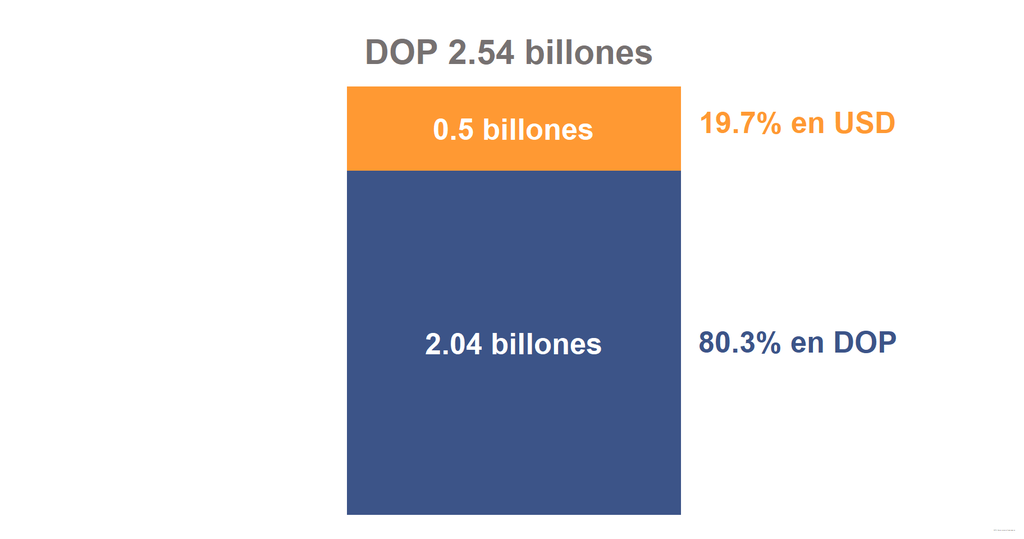

Los valores pueden emitirse en distintas monedas. La más popular es la moneda local, pero también hay opciones en dólares. Para ser exactos, el 80% del monto en circulación esta denominado en pesos y el restante 20% en dólares.

### 3. ¿En manos de quién están los valores de oferta pública?

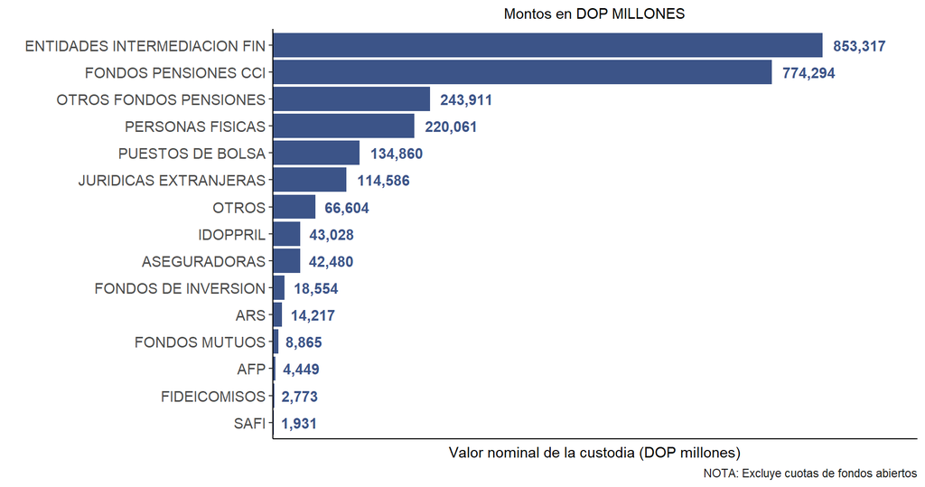

|  | Inversionista | Participantes | Monto (DOP millones) | % Total custodiado | labels |
| --- | --- | --- | --- | --- | --- |
| 1 | ENTIDADES INTERMEDIACION FIN | 39 | 853317 | 33.54 | 853,317 |
| 2 | FONDOS PENSIONES CCI | 7 | 774294 | 30.44 | 774,294 |
| 3 | OTROS FONDOS PENSIONES | 10 | 243911 | 9.59 | 243,911 |
| 4 | PERSONAS FISICAS | 23499 | 220061 | 8.65 | 220,061 |
| 5 | PUESTOS DE BOLSA | 14 | 134860 | 5.3 | 134,860 |
| 6 | JURIDICAS EXTRANJERAS | 21 | 114586 | 4.5 | 114,586 |
| 7 | OTROS | 697 | 66604 | 2.62 | 66,604 |
| 8 | IDOPPRIL | 1 | 43028 | 1.69 | 43,028 |
| 9 | ASEGURADORAS | 26 | 42480 | 1.67 | 42,480 |
| 10 | FONDOS DE INVERSION | 29 | 18554 | 0.73 | 18,554 |

[output cut: 6 more lines]

### 4. ¿Cuáles son los valores más populares?